# **Pulsar Star Classification**

[figure not shown]

*Fig. 1. A graphical representation of a pulsar star.*

## **Introduction**

**Background Information:**

Pulsars are rotating neutron stars that emit pulses of electromagnetic radiation (radio waves) at regular intervals (NRAO, New Mexico).

Investigating pulsar stars is important to the scientific community as they provide researchers with:

- Information about the physics of neutron stars (via the light they emit)
- Methods to accurately calculate cosmic distances (via the emission of electromagnetic [EM] radiation at systematic intervals)
- A “cosmic clock”; the intervals at which pulsar stars emit EM radiation can be used to help precisely tell time
- An instrument to detect gravitational waves

**Research Question:**

Given basic statistical features obtained from the integrated pulse profile and the DM-SNR curve, what stars classify as pulsar stars?

**Dataset Description:**

- The dataset we will be using is the HTRU2 (High Time Resolution Universe) dataset from the University of California Irvine (UCI) machine learning database.

**Statistical measurements of the integrated profile:**

- In pulsar stars, this profile will show regular periodicity and a very narrow pulse width on the integrated profile graph
- These two general assumptions of the integrated profile of pulsar stars can be used as a way to distinguish between pulsar and non-pulsar stars

**Statistical measurements of the DM-SNR curve:**

- The DM-SNR curve relates the dispersion measure and the signal-to-noise ratio (R.J. Lyon *et al.*)
- The DM-SNR curve can also be used to:
  - Estimate how far away a given pulsar is
  - Classify a given star as either pulsar or non-pulsar

Both of these measurements can be analyzed using basic statistical tools such as the mean, SD, and skewness, to essentially “create” new parameters that can be used to classify stars.

## Methods: Training the Model

**Variables:**

1. Mean of the integrated profile.
2. Standard deviation of the integrated profile.
3. Excess kurtosis of the integrated profile.
4. Skewness of the integrated profile.
5. Mean of the DM-SNR curve.
6. Standard deviation of the DM-SNR curve.
7. Excess kurtosis of the DM-SNR curve.
8. Skewness of the DM-SNR curve.
9. Class (Pulsar = 1, Non-Pulsar = 0)

**Data will be analyzed using the process outlined below:**

1. Split the data into training (75%) and testing (25%) datasets
2. Create a preprocessor that centers and scales the data (for all variables)
3. Create an object for the unspecified KNeighborsClassifier() method
4. Put both the preprocessor and the KNeighborsClassifier() object into a pipeline
5. Make a parameter grid dictionary that outlines a range of K values that will be tested
6. Using two objects, specify the first 8 variables as the predictors and the last variable “class”, as the target
7. Perform 10-fold cross-validation using both the GridSearchCV and RandomizedSearchCV methods
8. Create two data frames that display the results (e.g., mean test score) of each cross-validation method
9. Construct a visualization of each method’s results by plotting the mean test score (y-axis) vs the number of neighbours (x-axis)
10. Choose the K value (from the plot) with the highest mean test score
11. Re-train the model with this optimal K value
12. Predict on the test set to evaluate the model using the accuracy metric
13. Visualize the results using [PCA](https://en.wikipedia.org/wiki/Principal_component_analysis) and a confusion matrix to answer the analysis question

**Note:** We will do 8 different box plots, each plotting the distribution of a different feature within each of the binary star classes. Moreover, this will allow us to make generalizations about the effect each variable will have on the classification of an unknown star. Later in the report, we will utilize Principle Component Analysis to reduce the 8 features into 2 to visualize the results of the model and additionally use a confusion matrix to analyze the accuracy of the model with respect to each type of star.

**Methods FAQ**

**Why did we choose to build a K-nearest neighbours model?**

We built a K-nearest neighbours model as it is a well-regarded and frequently used algorithm for answering classification-based questions.

**Why & how are we going to do hyperparameter optimization?**

Hyperparameter optimization is necessary for choosing the optimal K value that yields the best testing accuracy. To carry out hyperparameter optimization, we will use both GridSearchCV and RandomizedSearch CV methods. We will then compare the graphical output of each method to choose the best value of K.

**Which predictor variables are we planning on using and why?**

We plan to use all of the variables given in the dataset because they are all useful tools in classifying a star, despite the fact that they are all different statistical measurements of the same raw instrumental data. Additionally, the dataset source suggested using all 8 variables if using them in a classification model.

## **Training the Classification Model**

```python
# Run this cell before continuing:

import pandas as pd
import altair as alt
from sklearn.model_selection import (
    GridSearchCV,
    RandomizedSearchCV,
    cross_validate,
    train_test_split)
import statistics
from sklearn.neighbors import KNeighborsClassifier
from sklearn.compose import make_column_transformer
from sklearn.preprocessing import StandardScaler
from sklearn.pipeline import Pipeline, make_pipeline
from sklearn.decomposition import PCA
from sklearn.metrics import accuracy_score
from sklearn.metrics import confusion_matrix
from sklearn.metrics import ConfusionMatrixDisplay
```

```python
# Demonstrate dataset can be read from web into python:

pulsar_data = pd.read_csv("HTRU_2.csv", names=[
"Mean_of_Integrated_Profile",
"SD_of_Integrated_Profile",
"Excess_kurtosis_of_the_integrated_profile",
"skewness_of_integrated_profile",
"Mean_of_the_DM-SNR_curve",
"SD_of_the_DM-SNR_curve",
"Excess_kurtosis_of_the_DM-SNR_curve",
"Skewness_of_the_DM-SNR_curve",
"class"])

pulsar_data
```

|  | Mean_of_Integrated_Profile | SD_of_Integrated_Profile | Excess_kurtosis_of_the_integrated_profile | skewness_of_integrated_profile | Mean_of_the_DM-SNR_curve | SD_of_the_DM-SNR_curve | Excess_kurtosis_of_the_DM-SNR_curve | Skewness_of_the_DM-SNR_curve | class |
| --- | --- | --- | --- | --- | --- | --- | --- | --- | --- |
| 0 | 140.562500 | 55.683782 | -0.234571 | -0.699648 | 3.199833 | 19.110426 | 7.975532 | 74.242225 | 0 |
| 1 | 102.507812 | 58.882430 | 0.465318 | -0.515088 | 1.677258 | 14.860146 | 10.576487 | 127.393580 | 0 |
| 2 | 103.015625 | 39.341649 | 0.323328 | 1.051164 | 3.121237 | 21.744669 | 7.735822 | 63.171909 | 0 |
| 3 | 136.750000 | 57.178449 | -0.068415 | -0.636238 | 3.642977 | 20.959280 | 6.896499 | 53.593661 | 0 |
| 4 | 88.726562 | 40.672225 | 0.600866 | 1.123492 | 1.178930 | 11.468720 | 14.269573 | 252.567306 | 0 |
| ... | ... | ... | ... | ... | ... | ... | ... | ... | ... |
| 17893 | 136.429688 | 59.847421 | -0.187846 | -0.738123 | 1.296823 | 12.166062 | 15.450260 | 285.931022 | 0 |
| 17894 | 122.554688 | 49.485605 | 0.127978 | 0.323061 | 16.409699 | 44.626893 | 2.945244 | 8.297092 | 0 |
| 17895 | 119.335938 | 59.935939 | 0.159363 | -0.743025 | 21.430602 | 58.872000 | 2.499517 | 4.595173 | 0 |
| 17896 | 114.507812 | 53.902400 | 0.201161 | -0.024789 | 1.946488 | 13.381731 | 10.007967 | 134.238910 | 0 |
| 17897 | 57.062500 | 85.797340 | 1.406391 | 0.089520 | 188.306020 | 64.712562 | -1.597527 | 1.429475 | 0 |

17898 rows × 9 columns

*Table 1. A pulsar star dataset downloaded from the web and stored in a pandas data frame.*

```python
# Summarize dataset in tables:

# NOTE: Because the values for each of the variables is on a much different scale,
# It will be necessary to use a standard scaler to give each variable appropriate weight in the classification model.
# We will split it into two seperate tables for readability purposes:

pulsar_training_class_0 = pulsar_data[pulsar_data["class"] == 0]
pulsar_training_class_1 = pulsar_data[pulsar_data["class"] == 1]

median_Mean_of_Integrated_Profile_0 = statistics.median(pulsar_training_class_0["Mean_of_Integrated_Profile"])
median_Mean_of_Integrated_Profile_1 = statistics.median(pulsar_training_class_1["Mean_of_Integrated_Profile"])
median_SD_of_Integrated_Profile_0 = statistics.median(pulsar_training_class_0["SD_of_Integrated_Profile"])
median_SD_of_Integrated_Profile_1 = statistics.median(pulsar_training_class_1["SD_of_Integrated_Profile"])
median_kurtosis_of_Integrated_Profile_0 = statistics.median(pulsar_training_class_0["Excess_kurtosis_of_the_integrated_profile"])
median_kurtosis_of_Integrated_Profile_1 = statistics.median(pulsar_training_class_1["Excess_kurtosis_of_the_integrated_profile"])
median_skewness_of_Integrated_Profile_0 = statistics.median(pulsar_training_class_0["skewness_of_integrated_profile"])
median_skewness_of_Integrated_Profile_1 = statistics.median(pulsar_training_class_1["skewness_of_integrated_profile"])

median_Mean_of_DM_SNR_0 = statistics.median(pulsar_training_class_0["Mean_of_the_DM-SNR_curve"])
median_Mean_of_DM_SNR_1 = statistics.median(pulsar_training_class_1["Mean_of_the_DM-SNR_curve"])
median_SD_of_DM_SNR_0 = statistics.median(pulsar_training_class_0["SD_of_the_DM-SNR_curve"])
median_SD_of_DM_SNR_1 = statistics.median(pulsar_training_class_1["SD_of_the_DM-SNR_curve"])
median_kurtosis_of_DM_SNR_0 = statistics.median(pulsar_training_class_0["Excess_kurtosis_of_the_DM-SNR_curve"])
median_kurtosis_of_DM_SNR_1 = statistics.median(pulsar_training_class_1["Excess_kurtosis_of_the_DM-SNR_curve"])
median_skewness_of_DM_SNR_0 = statistics.median(pulsar_training_class_0["Skewness_of_the_DM-SNR_curve"])
median_skewness_of_DM_SNR_1 = statistics.median(pulsar_training_class_1["Skewness_of_the_DM-SNR_curve"])

class_dataframe = pd.DataFrame(pulsar_data["class"].value_counts())
class_dataframe["Counts"] = [0, 1]
class_dataframe.rename(columns = {'class':'Counts', 'Counts':'Class'}, inplace = True)
class_dataframe = class_dataframe[["Class", "Counts"]]
class_dataframe["Median of the Mean of Integrated Profile"] = [median_Mean_of_Integrated_Profile_0, median_Mean_of_Integrated_Profile_1]
class_dataframe["Median of the SD of Integrated Profile"] = [median_SD_of_Integrated_Profile_0, median_SD_of_Integrated_Profile_1]
class_dataframe["Median of the Excess Kurtosis of Integrated Profile"] = [median_kurtosis_of_Integrated_Profile_0, median_kurtosis_of_Integrated_Profile_1]
class_dataframe["Median of the Skewness of Integrated Profile"] = [median_skewness_of_Integrated_Profile_0, median_skewness_of_Integrated_Profile_1]

class_dataframe_1 = pd.DataFrame(pulsar_data["class"].value_counts())
class_dataframe_1["Counts"] = [0, 1]
class_dataframe_1.rename(columns = {'class':'Counts', 'Counts':'Class'}, inplace = True)
class_dataframe_1 = class_dataframe_1[["Class", "Counts"]]
class_dataframe_1["Median of the Mean of DM Curve"] = [median_Mean_of_DM_SNR_0 , median_Mean_of_DM_SNR_1]
class_dataframe_1["Median of the SD of DM Curve"] = [median_SD_of_DM_SNR_0, median_SD_of_DM_SNR_1]
class_dataframe_1["Median of the Excess DM Curve"] = [median_kurtosis_of_DM_SNR_0, median_kurtosis_of_DM_SNR_1]
class_dataframe_1["Median of the Skewness of DM Curve"] = [median_skewness_of_DM_SNR_0, median_skewness_of_DM_SNR_1]
```

```python
class_dataframe
```

|  | Class | Counts | Median of the Mean of Integrated Profile | Median of the SD of Integrated Profile | Median of the Excess Kurtosis of Integrated Profile | Median of the Skewness of Integrated Profile |
| --- | --- | --- | --- | --- | --- | --- |
| 0 | 0 | 16259 | 117.257812 | 47.485647 | 0.186665 | 0.124107 |
| 1 | 1 | 1639 | 54.296875 | 37.341297 | 2.961258 | 11.609644 |

*Table 2. A table displaying the proportions of pulsar star and non-pulsar star Integregated Profile median values.*

```python
class_dataframe_1
```

|  | Class | Counts | Median of the Mean of DM Curve | Median of the SD of DM Curve | Median of the Excess DM Curve | Median of the Skewness of DM Curve |
| --- | --- | --- | --- | --- | --- | --- |
| 0 | 0 | 16259 | 2.635452 | 17.618420 | 8.760010 | 90.674592 |
| 1 | 1 | 1639 | 33.494983 | 59.367088 | 1.918327 | 2.585145 |

*Table 3. A table displaying the proportions of pulsar star and non-pulsar star DM Curve median values.*

```python
# Summarize dataset in a plot:

pulsar_chart_mean_integrated = (alt.Chart(pulsar_data[0:5000])
                .mark_boxplot()
                .encode(
        x=alt.X("class", title ="Class of Star", axis = alt.Axis(format='d', tickCount=1)),
        y=alt.Y("Mean_of_Integrated_Profile", title = "Mean of Integrated Profile"),
        )
).properties(
    title='Proportion of Mean of Integrated Profile'
)
pulsar_chart_SD_integrated = (alt.Chart(pulsar_data[0:5000])
                .mark_boxplot()
                .encode(
        x=alt.X("class", title ="Class of Star", axis = alt.Axis(format='d', tickCount=1)),
        y=alt.Y("SD_of_Integrated_Profile", title = "SD of Integrated Profile"),
        )
).properties(
    title='Proportion of SD of Integrated Profile'
)
pulsar_chart_kurtosis_integrated = (alt.Chart(pulsar_data[0:5000])
                .mark_boxplot()
                .encode(
        x=alt.X("class", title ="Class of Star", axis = alt.Axis(format='d', tickCount=1)),
        y=alt.Y("Excess_kurtosis_of_the_integrated_profile", title = "Excess kurtosis of Integrated Profile"),
        )
).properties(
    title='Proportion of Excess Kurtosis of Integrated Profile'
)
pulsar_chart_skewness_integrated = (alt.Chart(pulsar_data[0:5000])
                .mark_boxplot()
                .encode(
        x=alt.X("class", title ="Class of Star", axis = alt.Axis(format='d', tickCount=1)),
        y=alt.Y("skewness_of_integrated_profile", title = "Skewdness of Integrated Profile"),
        )
).properties(
    title='Proportion of Skewness of Integrated Profile'
)
pulsar_chart_integrated = alt.hconcat(pulsar_chart_mean_integrated, pulsar_chart_SD_integrated, pulsar_chart_kurtosis_integrated, pulsar_chart_skewness_integrated)
```

```python
pulsar_chart_mean_DM_SNR = (alt.Chart(pulsar_data[0:5000])
                .mark_boxplot()
                .encode(
        x=alt.X("class", title ="Class of Star", axis = alt.Axis(format='d', tickCount=1)),
        y=alt.Y("Mean_of_the_DM-SNR_curve", title = "Mean of DM-SNR curve"),
        )
).properties(
    title='Proportion of Mean of DM-SNR Curve'
)
pulsar_chart_SD_DM_SNR = (alt.Chart(pulsar_data[0:5000])
                .mark_boxplot()
                .encode(
        x=alt.X("class", title ="Class of Star", axis = alt.Axis(format='d', tickCount=1)),
        y=alt.Y("SD_of_the_DM-SNR_curve", title = "SD of DM-SNR curve"),
        )
).properties(
    title='Proportion of SD of DM-SNR Curve'
)
pulsar_chart_kurtosis_DM_SNR = (alt.Chart(pulsar_data[0:5000])
                .mark_boxplot()
                .encode(
        x=alt.X("class", title ="Class of Star", axis = alt.Axis(format='d', tickCount=1)),
        y=alt.Y("Excess_kurtosis_of_the_DM-SNR_curve", title = "Excess kurtosis of DM-SNR curve"),
        )
).properties(
    title='Proportion of Excess Kurtosis of DM-SNR Curve'
)
pulsar_chart_skewness_DM_SNR = (alt.Chart(pulsar_data[0:5000])
                .mark_boxplot()
                .encode(
        x=alt.X("class", title ="Class of Star", axis = alt.Axis(format='d', tickCount=1)),
        y=alt.Y("Skewness_of_the_DM-SNR_curve", title = "Skewdness of Integrated Profile"),
        )
).properties(
    title='Proportion of Skewness of DM-SNR Curve'
)
pulsar_chart_DM_SNR = alt.hconcat(pulsar_chart_mean_DM_SNR, pulsar_chart_SD_DM_SNR, pulsar_chart_kurtosis_DM_SNR, pulsar_chart_skewness_DM_SNR)
pulsar_chart = alt.vconcat(pulsar_chart_integrated, pulsar_chart_DM_SNR)
pulsar_chart.properties(title = alt.TitleParams(text = 'Proportion of Each Feature',
                                            fontSize = 40,
                                            anchor='middle')
                        )
```

[interactive chart not shown]

*Fig. 2. Box plots that visualize the proportion of each feature for both pulsar and non-pulsar stars.*

From the graphs above, you can infer that there is a clear difference between pulsar (1) and non-pulsar stars (0) for each predictor variable. This should hopefully result in a K-nearest neighbours model that produces sufficiently accurate predictions.

```python
# First, scale the data:

pulsar_data_preprocessor = make_column_transformer(
     (StandardScaler(), ["Mean_of_Integrated_Profile",
                         "SD_of_Integrated_Profile",
                         "Excess_kurtosis_of_the_integrated_profile",
                         "skewness_of_integrated_profile",
                         "Mean_of_the_DM-SNR_curve",
                         "SD_of_the_DM-SNR_curve",
                         "Excess_kurtosis_of_the_DM-SNR_curve",
                         "Skewness_of_the_DM-SNR_curve"]),
)

pulsar_data_scaled = pd.DataFrame(
     pulsar_data_preprocessor.fit_transform(pulsar_data),
     columns=[
    "Mean_of_Integrated_Profile",
    "SD_of_Integrated_Profile",
    "Excess_kurtosis_of_the_integrated_profile",
    "skewness_of_integrated_profile",
    "Mean_of_the_DM-SNR_curve",
    "SD_of_the_DM-SNR_curve",
    "Excess_kurtosis_of_the_DM-SNR_curve",
    "Skewness_of_the_DM-SNR_curve",
     ],
)

# Add the class column back into the data frame:

pulsar_data_scaled["class"] = pulsar_data["class"]


# Split dataset into training (75%) and testing (25%):

pulsar_training, pulsar_testing = train_test_split(
     pulsar_data_scaled, test_size=0.25, random_state=2000)
```

```python
# Begin hyperparameter tuning by first creating a parameter grid
# Then, incorporate this grid into a pipeline along with the model specification:

param_grid = {
    "kneighborsclassifier__n_neighbors": range(1, 1001, 100),
}
pulsar_pipe = make_pipeline(pulsar_data_preprocessor, KNeighborsClassifier())
```

```python
# Next, run 10-fold cross-validations to tune hyperparameters:

knn_tune_grid = GridSearchCV(
    pulsar_pipe, param_grid, cv=10,
)
knn_tune_random = RandomizedSearchCV(
     pulsar_pipe, param_grid, n_iter=10, cv=10, random_state=69420
)
```

```python
# Fit each model to the training data
# and extract the cross validation results:

X_tune = pulsar_training[[
"Mean_of_Integrated_Profile",
"SD_of_Integrated_Profile",
"Excess_kurtosis_of_the_integrated_profile",
"skewness_of_integrated_profile",
"Mean_of_the_DM-SNR_curve",
"SD_of_the_DM-SNR_curve",
"Excess_kurtosis_of_the_DM-SNR_curve",
"Skewness_of_the_DM-SNR_curve"]]

y_tune = pulsar_training["class"]

pulsar_model_grid = knn_tune_grid.fit(X_tune,y_tune)
pulsar_model_random = knn_tune_random.fit(X_tune,y_tune)

pulsar_accuracies_grid = pd.DataFrame(pulsar_model_grid.cv_results_)
pulsar_accuracies_random = pd.DataFrame(pulsar_model_random.cv_results_)
```

```python
# Plot the results of GridSearchCV and RandomizedSearchCV:

accuracy_versus_k_grid = (
    alt.Chart(pulsar_accuracies_grid, title="Grid Search KNN Results")
    .mark_line(point=True)
    .encode(
        x=alt.X("param_kneighborsclassifier__n_neighbors"
            ,
            title="Neighbors",
            scale=alt.Scale(zero=False),
        ),
        y=alt.Y("mean_test_score"
            ,
            title="Mean Test Score",
            scale=alt.Scale(zero=False)
        ),
    )
)

accuracy_versus_k_random = (
    alt.Chart(pulsar_accuracies_random, title="Randomized Search KNN Results")
    .mark_line(point=True)
    .encode(
        x=alt.X("param_kneighborsclassifier__n_neighbors"
            ,
            title="Neighbors",
            scale=alt.Scale(zero=False),
        ),
        y=alt.Y(
            "mean_test_score",
            title="Mean Test Score",
            scale=alt.Scale(zero=False)
        ),
    )
)

accuracy_grid_random = alt.hconcat(accuracy_versus_k_grid, accuracy_versus_k_random)
```

```python
accuracy_grid_random
```

[interactive chart not shown]

```python
# Perform GridSearchCV and RandomizedSearchCV
# with smaller range of k values to optimize
# the model's accuracy:

param_grid = {
    "kneighborsclassifier__n_neighbors": range(1, 51, 1),
}

pulsar_pipe = make_pipeline(pulsar_data_preprocessor, KNeighborsClassifier())

knn_tune_grid = GridSearchCV(
    pulsar_pipe, param_grid, cv=10,
)
knn_tune_random = RandomizedSearchCV(
     pulsar_pipe, param_grid, n_iter=10, cv=10, random_state=69420
)

pulsar_model_grid = knn_tune_grid.fit(X_tune,y_tune)
pulsar_model_random = knn_tune_random.fit(X_tune,y_tune)

pulsar_accuracies_grid = pd.DataFrame(pulsar_model_grid.cv_results_)
pulsar_accuracies_random = pd.DataFrame(pulsar_model_random.cv_results_)

accuracy_versus_k_grid = (
    alt.Chart(pulsar_accuracies_grid, title="Grid Search KNN Results")
    .mark_line(point=True)
    .encode(
        x=alt.X("param_kneighborsclassifier__n_neighbors"
            ,
            title="Neighbors",
            scale=alt.Scale(zero=False),
        ),
        y=alt.Y("mean_test_score"
            ,
            title="Mean Test Score",
            scale=alt.Scale(zero=False)
        ),
    )
)

accuracy_versus_k_random = (
    alt.Chart(pulsar_accuracies_random, title="Randomized Search KNN Results")
    .mark_line(point=True)
    .encode(
        x=alt.X("param_kneighborsclassifier__n_neighbors"
            ,
            title="Neighbors",
            scale=alt.Scale(zero=False),
        ),
        y=alt.Y(
            "mean_test_score",
            title="Mean Test Score",
            scale=alt.Scale(zero=False)
        ),
    )
)

accuracy_grid_random = alt.hconcat(accuracy_versus_k_grid, accuracy_versus_k_random)
```

```python
accuracy_grid_random
```

[interactive chart not shown]

*Fig. 4. Scatter plots showing the KNN Mean Test Score results for Grid Search and Randomized Search for K values from 1 to 50.*

From the graphs above, we can conclude that a K value of 3 or 4 should result in the highest testing accuracy. We will use 3 and move on to testing our model on the testing data to see if we achieve similar testing accuracy.

## **Results: Testing the Classification Model**

```python
# Grab testing data:

X_test = pulsar_testing[[
"Mean_of_Integrated_Profile",
"SD_of_Integrated_Profile",
"Excess_kurtosis_of_the_integrated_profile",
"skewness_of_integrated_profile",
"Mean_of_the_DM-SNR_curve",
"SD_of_the_DM-SNR_curve",
"Excess_kurtosis_of_the_DM-SNR_curve",
"Skewness_of_the_DM-SNR_curve"]]

y_test = pulsar_testing["class"]

# Use optimal K value to train KNN model
# with training data:

optimal_k = 3
knn = KNeighborsClassifier(n_neighbors=optimal_k)
knn.fit(X_tune, y_tune)

# Test KNN model with testing data:

y_pred = knn.predict(X_test)
```

```python
# Use Principle Component Analysis to visualize
# the testing data. You do not need to fully understand
# this as it was not covered in this course.
# BASICALLY, PCA can reduce d = 8 features to d = 2:

pca = PCA(n_components = 2)
X_pca = pca.fit_transform(X_test)
df = pd.DataFrame({'PC1': X_pca[:, 0], 'PC2': X_pca[:, 1], 'label': y_test})

scatter1 = alt.Chart(df).mark_circle(size=100).encode(
    x='PC1',
    y='PC2',
    color=alt.Color('label', scale=alt.Scale(scheme='category20'))
).properties(
    width=600,
    height=400,
    title='PCA Form of Testing Data'
)

# Use PCA dimension reduction to
# visualize KNN results:

pca = PCA(n_components = 2)
X_pca = pca.fit_transform(X_test)
df = pd.DataFrame({'PC1': X_pca[:, 0], 'PC2': X_pca[:, 1], 'label': y_pred})

scatter2 = alt.Chart(df).mark_circle(size=100).encode(
    x='PC1',
    y='PC2',
    color=alt.Color('label', scale=alt.Scale(scheme='category20'))
).properties(
    width=600,
    height=400,
    title='PCA Form of KNN Results'
)

scatter_final = alt.vconcat(scatter1, scatter2)

# Also, print the model's testing accuracy:

print(accuracy_score(y_test, y_pred))


scatter_final
```

```
0.9767597765363129
```

[interactive chart not shown]

*Fig. 5. Scatter plots showing the original test data with its actual classification and the KNN model predictions using the test data. Principle component analysis decreases 8 features into 2 for visualization purposes.*

As pictured above, the actual class distribution and the predicted class distribution are similar in both shape and spread. However, in the case of the predicted output (bottom plot) certain observations were misclassified (i.e., light blue dots appearing in a dark blue cluster, and vice-versa).

```
<sklearn.metrics._plot.confusion_matrix.ConfusionMatrixDisplay at 0x22267cee490>
```

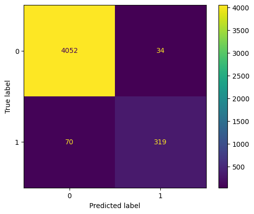

```python
# Can also visualize the KNN
# results with a confusion matrix:

cm = confusion_matrix(y_test, y_pred)

disp = ConfusionMatrixDisplay(
    confusion_matrix=cm)

disp.plot()
```

*Fig. 6. A confusion matrix that shows the results of the KNN model when predicting the test data.*

From the above, we can see why the model is so accurate. There are a large number of true negatives in our dataset and relatively few true positives. This indicates that the model is very good at predicting non-pulsar stars, but is less accurate at predicting stars that are pulsars. In the PCA charts shown above, this small lack of accuracy is seen in the KNN results which have less overlap than the testing data plot. Due to the extremely high accuracy of the KNN model for such a large range of K values, this confusion matrix is a better metric of accuracy since it shows the accuracy of predictions for both classes of stars separately, as it displays the number of correct and incorrect predictions for each true class.

## **Discussion**

**Summary of results:**

Based on the output above, it was found that our model accurately predicted non-pulsar stars, yielding a mean-test score of 99%. However, our model was also found to be less accurate at predicting pulsar stars, yielding a lower mean-test score of 82%.

Although the high accuracy of the model was a positive result, it wasn't expected that the accuracy would be so high due to the nature of KNN classification. This high accuracy is likely a result of the large class imbalance in the original dataset that had significantly more non-pulsar stars than pulsar stars. Despite this class imbalance, the confusion matrix is able to better represent the true accuracy of the model with respect to each class separately as it shows the number of correct and incorrect predictions for each class.

For this model, the process of determining the best K value to use in the classification process was relatively complicated due to the class composition of the original dataset and it's skewed distribution. This made it so that the model consistently had a very high accuracy, likely due to it's ability to classify any star as non-pulsar, over a very large range of K. In the end, the best K was found to be 3, but any value of K between 3 and about 1000 resulted in a test accuracy above 90%, meaning that the chosen K value had a very small impact on the overall output of the model.

**Impact of findings:**

Based on the current science behind pulsars and the ways they are used to measure and observe the universe, being able to more easily classify a star as pulsar or non-pulsar could streamline future efforts to advance our knowledge of the cosmos. Of course, because the classification model only showed an accuracy of 82% on true pulsars, further experiments would be required. These experiments would need to either develop a more accurate prediction model, or examine each predicted pulsar more closely using different astronomical features to determine its true class. Otherwise, blindly following the classification model could lead to misinformed conclusions as it may result in the misclassification of new stars.

**Future questions:**

- Would a balanced data set (i.e., one with a roughly equal amount of pulsar and non pulsars) yield different prediction accuracies? If so, would these predictions be more or less accurate than the current model?
- What other data science algorithms could be implemented to more accurately predict pulsar or non-pulsar stars?
  - For example, would it be possible to develop a model that can predict the likelihood of a star being a pulsar?
- Can the statistical measures applied by this model be used to classify other types of neutron stars? (e.g., Magnetars, X-ray pulsars, etc.) (Singularity, 2019)
- Other than star type, what other cosmic phenomena could be classified using the K-nearest neighbours algorithm?
- Does the ability to easily classify pulsar stars advance current research into the circumstances that led to their formation?
- Would using less features result in more accurate predictions for pulsar or non-pulsar stars?

**Works Cited**

Lea, R. (2016, April 22). What are pulsars? Space.com. Retrieved March 10, 2023, from https://www.space.com/32661%5C-pulsars.html

Lyon, R. J., Stappers, B. W., Cooper, S., Brooke, J. M., & Knowles, J. D. (2016). Fifty years of pulsar candidate selection: from simple filters to a new principled real-time classification approach. MNRAS, 459, 1104–1123. https://doi.org/10.1093/mnras/stw656

Lyon, R. J. (2016). Why Are Pulsars Hard To Find? (thesis).

NRAO. (2012, February 20). Pulsars: The Universe's gift to physics. Astronomy.com. Retrieved March 10, 2023, from https://astronomy.com/news/2012/02/pulsars%5C-%5C-%5C-the%5C-universes%5C-gift%5C-to%5C-physics

Singularity. (2019, July 21). 9 breathtaking types of neutron stars that you can't miss to know about. Medium. Retrieved April 7, 2023, from [https://medium.com/@sin\_gularity/9\-types\-of\-neutron\-stars\-3566cb18c7b8](https://medium.com/@sin_gularity/9-types-of-neutron-stars-3566cb18c7b8)

UCI Machine Learning Repository: HTRU2 data set. (n.d.). Retrieved March 10, 2023, from https://archive.ics.uci.edu/ml/datasets/HTRU2